# **Supplementaty PCS Documentation: Does increasing model complexity and incorporating additional variables improve the prediction ability and model transportability of live birth prediction models for donor egg IVF?**

Alissa Chaitarvornkit, Georgina M Chambers, Damian P Kotevski, Vinayak Smith, Oisin Fitzgerald

# **1.Overview**

### Study Question

This study investigates whether using more complex machine learning models and additional variables could improve prediction ability and model transportability for predicting the chance of having a live birth following donor egg assisted reproductive technology (ART) treatment, also commonly referred to as “IVF”.

### Background

Accurate estimations of IVF success allow patients to make informed decisions on their treatment and set realistic expectations. Currently there are only two publicly available donor egg IVF prediction tools available to patients, the Fitzgerald and Luke model (Fitzgerald et al., 2024; Luke et al., 2014). However, they rely on fewer predictor variables, use traditional statistical models and operate on outdated data. Exploring models of varying complexity, in addition to additional predictor variables, could provide more accurate and personalised estimations as well as robust across different populations.

### Study design

Eight prediction models (linear, tree-based, distance-based, semi-parametric, and neural networks) were developed using 8,380 Australian donor egg embryo transfer cycles with thirteen patient and treatment characteristics. Model performance was benchmarked against the publicly available prediction model, the Fitzgerald model, also known as the donor egg YourIVFSuccess Estimator. The models underwent internal validation, external validation on 1,173 New Zealand treatment cycles and reverse external validation to assess model transportability. Permutation feature importance and accumulated local effects plots assessed the effects of the additional variables across the models.

### PCS Framework

The purpose of this supplementary documentation is to provide transparency and justification on the steps towards the analysis and model development as well as stability analyses towards the developed models. It follows the Predictability, Computability and Stability (PCS) framework for veridical data science (Yu & Kumbier, 2020).

### Model development pipeline

The general pipeline of the model development and evaluation is as follows: data curation, data pre-processing, model training and optimisation, model evaluation, feature importance and interpretation analysis

# **2.Data**

## **2.1 Data overview**

### Dataset overview

The data was sourced from the Australia and New Zealand Assisted Reproduction Database (ANZARD), which is a population level clinical quality registry that captures all the data from IVF services across Australia and New Zealand. It captures information about the patient, treatment and outcomes and had been previously used to develop the YourIVFSuccess Estimator, hence making it a suitable dataset to develop and validate clinical prediction models.

### Connection to the domain problem

ANZARD collects treatment and birth outcome information for all cases where donor egg IVF treatments were performed across Australia and New Zealand. Given that it is a complete coverage dataset, has undergone extensive validation and quality assurance as part of the registry standard and offers a comprehensive range of collected information, it offers a high-quality dataset to develop models on. Furthermore, by using the same registry source as the YourIVFSuccess Estimator, it enables direct benchmarking against the current tool with the newly developed models.

## **2.2 Data Collection**

### Data collection

This study utilises retrospective ANZARD data between 2020-2024, as ANZARD 3.0 variables became available from 2020 onwards and 2024 is the most recent complete year. The study population is restricted to egg recipient females undergoing their first donor egg embryo transfer during this period, so that it allows tracing of live birth outcomes attributed to the initial treatment. The eligibility and exclusion criteria were adapted from the study Oisin et al, which developed the YourIVFSuccess donor egg Estimator, which allows direct benchmarking with the models developed in this study. Thirteen variables, ranging from patient and treatment characteristics, were chosen based on domain knowledge, existing literature, data availability and the chance to further personalise the YourIVFSuccess donor egg Estimator. The Australian cohort was used to develop and internally validate the models, whereas the independent New Zealand cohort was reserved for external validation. Furthermore, reverse external validation was subsequently done by training the models on the New Zealand cohort and evaluating them on the Australian cohort. This study design was chosen as the current YourIVFSuccess egg donor Estimator is developed using Australian data and is intended for the Australian clinical practice, hence making this cohort appropriate as the development dataset.

### Data limitation

Despite the dataset having a comprehensive population level coverage of donor egg IVF treatments, there are several limitations to the dataset. Since some variables were only collected when the new ANZARD 3.0 version came out in 2020, so the analysis is restricted to data collected from 2020 onwards, which limits the sample size and follow-up period. Some new variables of interest could not be included because they were only applicable to female-male intending parents which reduces the usefulness across the study cohort and limiting the development of an inclusive model. Furthermore, donor information is limited to donor age only, which limits the ability to determine whether other donor factors could influence live birth outcomes.

### Data accessibility

The ANZARD data is stored on a UNSW managed server in accordance with the registry’s governance and ethical requirements. As the dataset is classified as highly sensitive, it is not publicly available. It is restricted to authorised users with appropriate ethical approval and permission from the ANZARD data custodian.

## **2.3 Data Splitting**

The dataset was split into 70% training and 30% testing sets at a patient level, to ensure all treatments from the same patient was within the same partition. This prevented cycle level leakage, whereby multiple cycles from a single patient would have been split across the two datasets. The split was stratified by live birth and remained unbalanced (at around 30% success rate), to reflect real world probability of donor egg IVF outcomes (Figure 1-3).

The 70%/30% ratio split was chosen as it provides sufficient data for model development, whilst having an adequate size test dataset (Bichri et al., 2024; Nguyen et al., 2021). The test dataset was held out throughout the model development such performance can be evaluated in an unbiased manner.

Within the training dataset, repeated stratified 10-fold cross validation (3 repeats) was done to tune the hyperparameters of the models. Hyperparameters were chosen based on the lowest AUC-ROC error, the primary metric used throughout the study which provides a consistent model comparison.

Repeated 10-fold cross validation was selected as it had been shown to reduce variability of performance when compared to non-repeated validation methods (Kim, 2009). Ten-fold was chosen as it is one of the most recommended resampling folds in predictive modelling and in this study showed negligible effects on the predictive performance when compared to the 3 and 5-fold cross validation (± 0.002 mean AUC-ROC) and not substantial computational cost (Figure 4). The number of repeats was chosen by evaluating the predictive performance of GAM across various commonly used repeat scenarios (repeats of 1, 3, 5, 10). Increasing the number of repeats slightly improved predictive performance though negligible (± 0.0009 mean AUC-ROC) despite substantially increasing the computational time (Figure 5). Therefore 3 repeats were chosen with the balance of computational efficiency and predictive performance.

### Live birth outcome variable data split

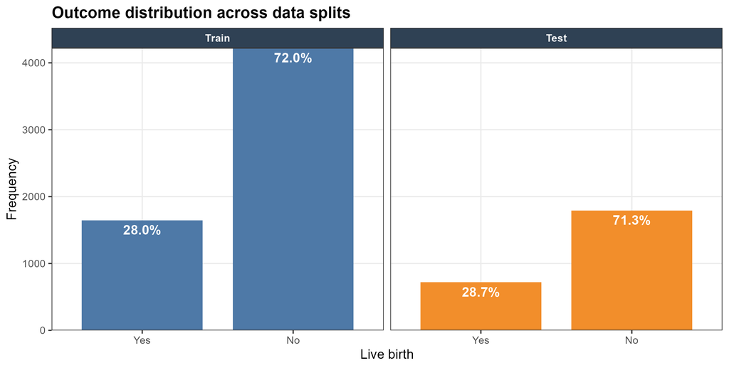

**Figure 1.** Distribution of the live birth outcomes across the 70% training and 30% testing dataset. Bar plots show the frequency of training (blue) and test (orange) following the 70%/30% stratified patient-level split. Percentages displayed represent the proportion within each training or testing dataset.

### Categorical predictor variable data split

[figure not shown]

**Figure 2.** Distribution of the categorical predictor variables across the training and testing datasets following the patient-level stratified 70%/30% split. Bar plots show the frequency of each category in the training (blue) and test (orange) dataset. Percentages displayed represent the proportion within each training or testing dataset.

### Numerical predictor variable data split

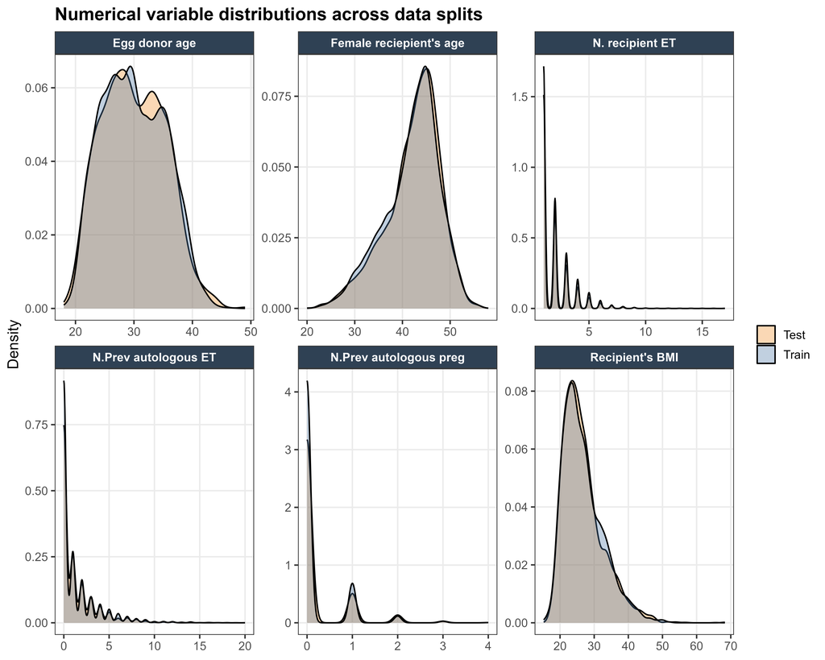

**Figure 3.** Distribution of numerical predictor variables across the training and test datasets following the patient-level stratified 70%/30% split. Kernel density plots compared the distribution across the training (blue) and test (orange) datasets.

### K-fold analysis

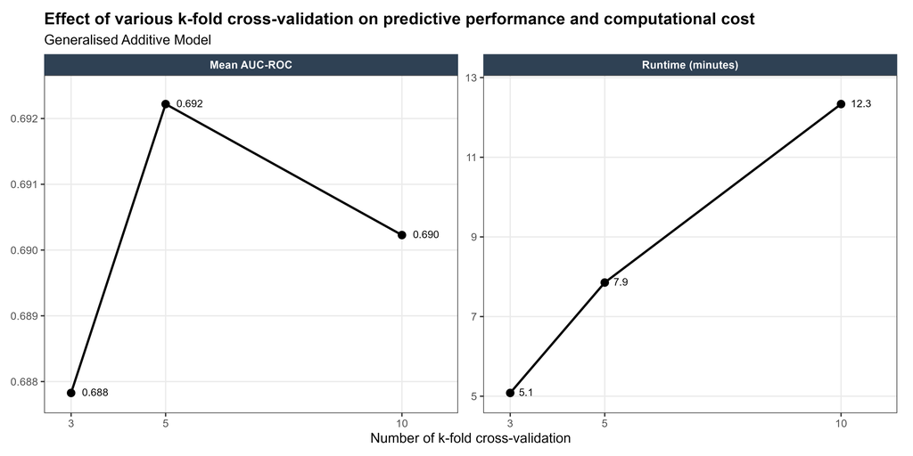

**Figure 4.** Effect of various k-folds on 1x repeat cross-validation on predictive performance and computational cost using the Generalised Additive Model.

### Repeat analysis

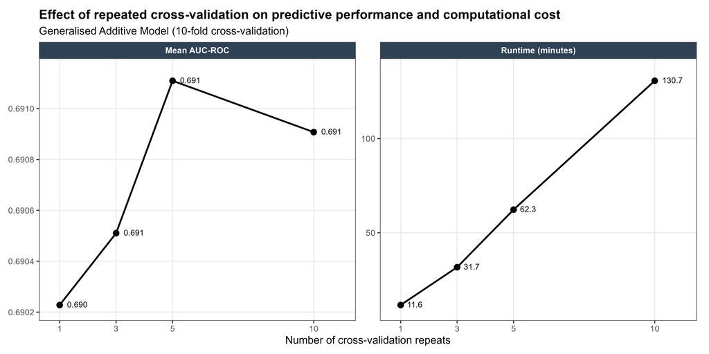

**Figure 5.** Effect of various repeats on 10-fold cross-validation on predictive performance and computational cost using the Generalised Additive Model.

## **2.4 Data cleaning and preprocessing**

### Development environment

Model development was conducted in R.4.5.2 using RStudio. Primary packages included recipes (Kuhn & Wickham, 2024) and caret (Kuhn, 2023) to implement a reproducible processing pipeline and a unified framework for model training, tuning and evaluation. Data.table (Dowle et al., 2019) and dplyr (Wickham et al., 2023) for efficient data manipulation, and ggplot2 (Wickham et al., 2016) was used for its publication quality visualisations (Table 1).

**Table 1.** Packages used to develop the IVF prediction models using donor eggs, within the R Studio environment. Packages predominantly handled data processing, model development, evaluation and visualisation.

| Package | Version | Reference |
| --- | --- | --- |
| data.table | 1.18.4 | Dowle et al. (2019) |
| dplyr | 1.2.1 | Wickham et al. (2023) |
| naniar | 1.1.0 | Tierney (2023) |
| rsample | 1.3.2 | Foster et al. (2023) |
| recipes | 1.3.3 | Kuhn & Wickham (2024) |
| caret | 7.0-1 | Kuhn (2023) |
| lubridate | 1.9.5 | Spinu et al. (2023) |
| tibble | 3.3.1 | Wickham et al. (2023) |
| Metrics | 0.1.4 | McShane & Albert (2022) |
| PRROC | 1.4 | Nathan et al. (2021) |
| iml | 0.11.4 | Molnar (2022) |
| ggplot2 | 4.0.3 | Wickham et al. (2016) |
| plotROC | 2.3.3 | Sachs (2017) |
| ggdensity | 1.0.1 | Otto (2023) |
| cowplot | 1.2.0 | Wilke (2024) |

### Data cleaning and preprocessing

Data cleaning and preprocessing was done to ensure the data was clinically plausible whilst acceptable for the model training.

Distributions were evaluated and values that were out of range were set to missing (Figure 6-7). In this case the recipient BMI values (<15 kg/m² severely underweight or >70 kg/m² morbidly obese), were set to NA. Variables coded as ‘unknown’ using a placeholder value (e.g. age = 99) were also converted to NA, to prevent artificial values influencing the model.

Variables were screen for near zero variance and high pairwise correlation to identify any potential variables that could disproportionately skew the model fitting or obscure other potential predictors (Toloşi & Lengauer, 2011). Spearman’s rank correlation coefficient was chosen as the data presented non-linear relationships amongst the variables (Figure 8).

Preprocessing was done independently within the training and test datasets to prevent information leakage. As algorithms require data to be presented in a certain format, preprocessing steps such as transforming categorical variables, standardising continuous variables and imputing missing values are needed.

Categorical variables were converted to one-hot encoded binary variables due to the input requirements of models such as neural networks. Continuous variables were centred and scaled to fit within a unified range, which is a requirement for distance-based and regularised models like K-nearest neighbours (KNN).

Missing values were imputed using KNN imputation (k = 5). Overall, the missingness was low, with recipient BMI having the highest proportion of missing (approximately 6%) (Figure 9). Other variables ranged from 0.4-0.8% missing values. As the level of missingness was quite low, there was enough data to make an accurate imputation. Various imputation methods were evaluated to see which imputation created the least AUC-ROC error in a sensitivity analysis, with KNN = 5 proving the lowest imputation error and therefore chosen in the pipeline (Figure 10).

#### Numerical variable summary

[figure not shown]

**Figure 6.** Pairwise relationship between numerical variables during the model development. The diagonal panel shows the distribution of each variable using kernel density plots, the lower panels display the scatter plots split by live birth (pink) and no live birth (blue) cohorts and the upper quadrant presents the Spearman correlation coefficients for overall cohort (black), live birth (pink) and no live birth (blue). Significant levels indicated as *P* < 0.05 (*), *P* < 0.01 (**) and *P* < 0.001 (***).

#### Categorical variable summary

[figure not shown]

**Figure 7.** Distribution of categorical variables stratified by live birth outcome, live birth = Yes (red) and live birth = No (blue). Percentage displayed on each bar plot represents the proportion of each variable group within the live birth outcome group.

#### Correlation plot

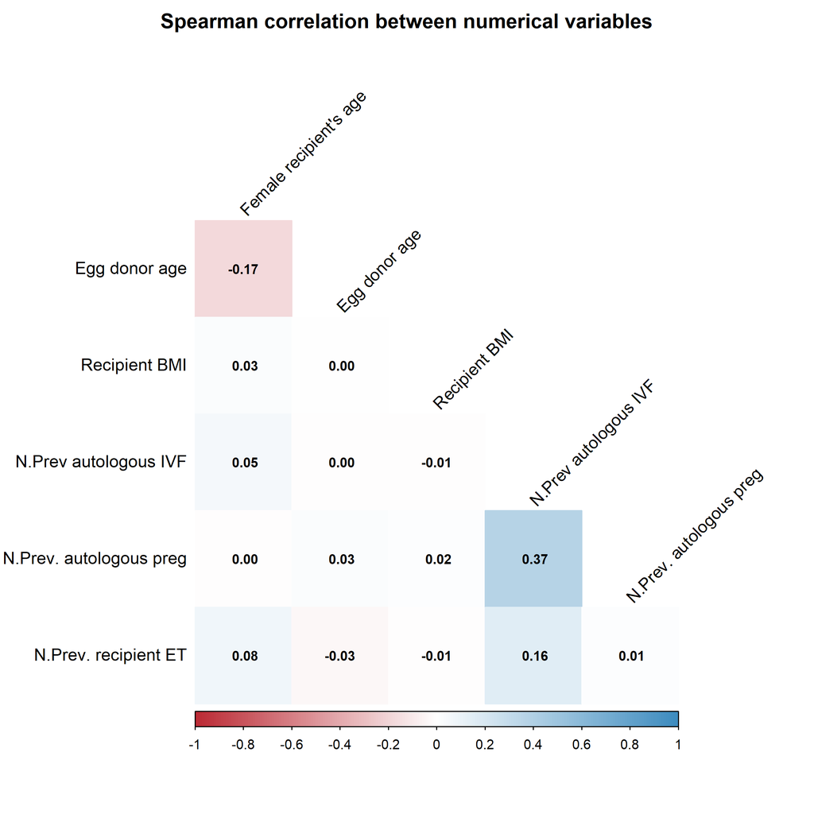

**Figure 8.** Spearman correlation matrix of numerical predictor variables.

#### % Missing

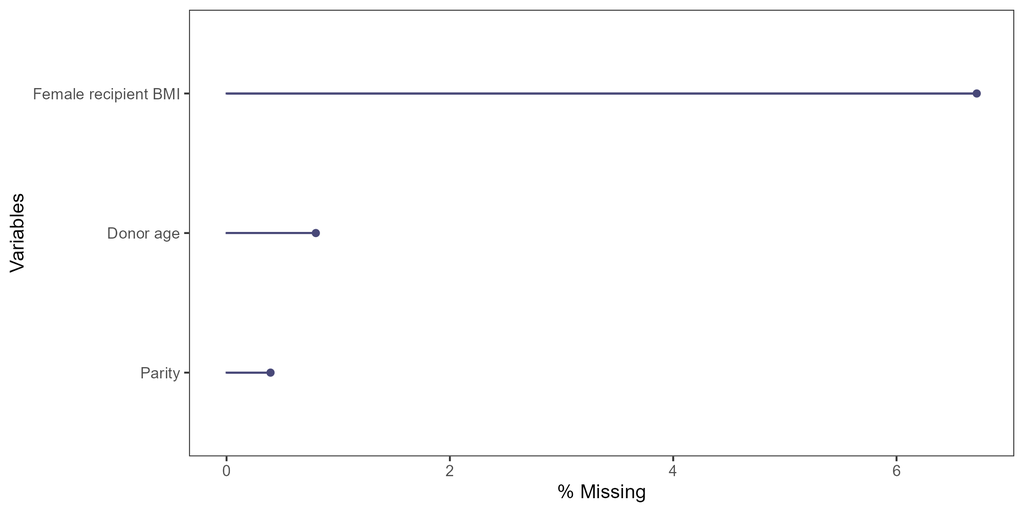

**Figure 9.** Proportion (%) of each variable that has missing data points.

#### Imputation analysis

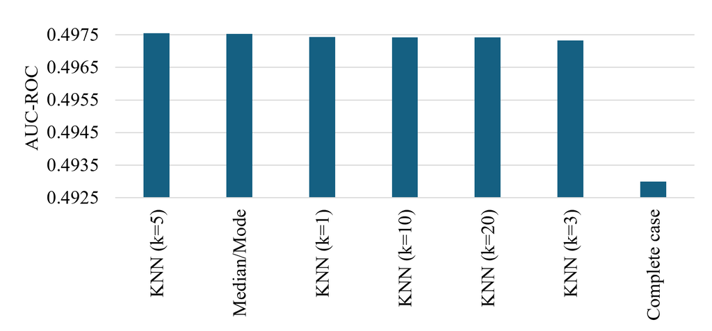

**Figure 10.** Comparison of AUC-ROC performance of logistic regression models trained using different missing data handling strategies, including complete case, median/mode imputation and K-nearest neighbours (KNN) imputation on varying neighbour sizes (k = 1,3,5,10,20). Methods are ordered from highest to lowest AUC-ROC performance.

# **3.Prediction modelling**

## **3.1 Modelling methods**

The prediction outcome was a live birth outcome after a donor egg embryo transfer, therefore making it appropriate for classification. The goal of the study was to assess whether model complexity influenced prediction outcomes, therefore a diverse range of classification models spanning various levels of complexity and interpretability were chosen. The models included:

- Logistic regression (LR) as it is a widely used approach for classification
- Regularised logistic regression (regLR) as it provides an insight to whether penalisation improves generalisability of LR whilst maintaining interpretability
- Generalised additive models (GAM) as it serves as a baseline model that was used in the YourIVFSuccess Estimator and can capture non-linear relationships through splines
- Decision trees (DT) as it is a simple interpretable non-linear tree form model
- Random forest (RF) as it is an ensemble method of decision trees that can handle large complex datasets but is less interpretable
- Extreme gradient boosting (XGBoost) as it is a state-of-the-art algorithm capable of handling complex non-linear relationships and incorporates regularisation however is less interpretable
- Neural networks (NN) as it utilises deep learning networks of non-linear relationships however is less interpretable
- K-nearest neighbours (KNN) as it uses non-parametric distance-based learning methods

The publicly available YourIVFSuccess Estimator was used as a benchmark against the models developed in this study. To ensure a consistent comparison, it was evaluated against the updated data between 2020-2024.

### Evaluation metrics

Three metrics were chosen to assess the models in various ways. AUC-ROC measures a model’s ability to distinguish between the classes. AUC-PR measures how well a model can identify the positive class, which can be particularly useful if the data is imbalanced, which it is in our case, and finally the Brier score which is a joint measure of a model’s calibration and discrimination (Helen R. Sofaer, 2018). All three metrics was taken into consideration, with the top performing model having a well-rounded outcome across the three.

To assess model stability confidence intervals (CI) of 95% was calculated of the model outcomes using the bootstrap method, resampling the test dataset 1000 times. This provides an insight into the variability of model predictive performance in the test cohort through repeated resampling (Johns, 1988).

## **3.2 Prediction check**

The eight models were trained using the 70% training dataset following the preprocessing pipeline. A grid search of hyperparameters was tuned during the 3x repeated 10-fold cross validation process, where the hyperparameter was chosen with the lowest AUC-ROC error (Table 2).

### Hyperparameter tuning

**Table 2.** Hyperparameter tuning results and explored parameters for the eight IVF prediction models during the model development component.

[output not shown]

### Training confusion matrix

**Table 3.** Confusion matrices for the models during training 3x repeated 10-fold cross validation.

[output not shown]

### Internal validation metrics

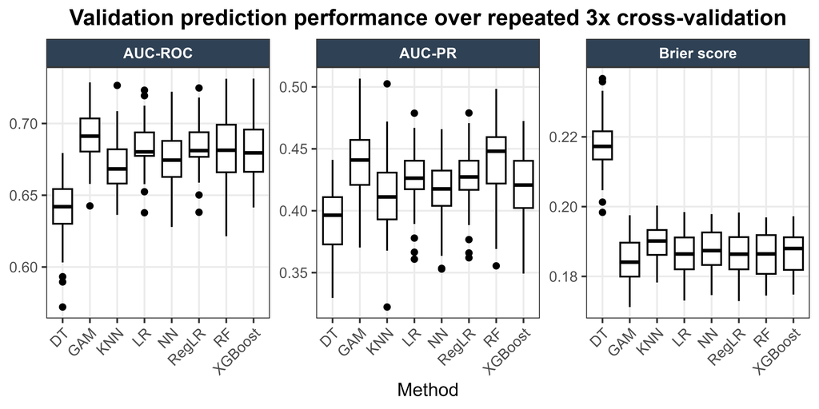

**Figure 11.** Internal validation performance across 3x repeated 10-fold cross validation. Boxplots visualise the distribution across AUC-ROC, AUC-PR and Brier Scores for each prediction model across the 30 held out validation folds.

## **3.3 Stability check**

Model stability was assessed across several steps to determine whether performance remained consistent across the cross validation of the training dataset through to external validations. During the cross validation, all models except decision tree (DT) demonstrated stable performance across the three evaluation metrics. The DT showed greatest variability and poorer performance, indicating it is sensitive to changes in the training data. Test/train ROC plots indicated that the models predicted consistency across the test/train subsets, indicating low risk of overfitting (Figures 12-19).

Calibration plots generated from the test dataset were used to inspect the model’s prediction probability to the observed live birth outcome. It highlights the confidence of the model’s prediction (Figures 20-27). All models except DT had good calibration, particularly within the relevant clinical range of 10-40%, whereby 30% is reflected in the real-world scenario.

To quantify the uncertainty of the models during the testing phase, 95% confidence intervals were generated across the three-evaluation metrics using 1000 bootstrap resamples of the test dataset. Narrower confidence intervals indicated greater precision on the performance metrics and increase confidence in the model’s prediction. Model stability was assessed through external validation using the New Zealand cohort, detailed more in Chapter 4. Validaiton Outcomes. Here, performance was generally maintained with only minor metric shifts. Model transportability was further assessed using reverse external validation by training the models on New Zealand data and testing it on the Australian cohort. This helped assess whether the change in metrics was due to population differences rather than model instability.

### **ROC plots**

#### LR

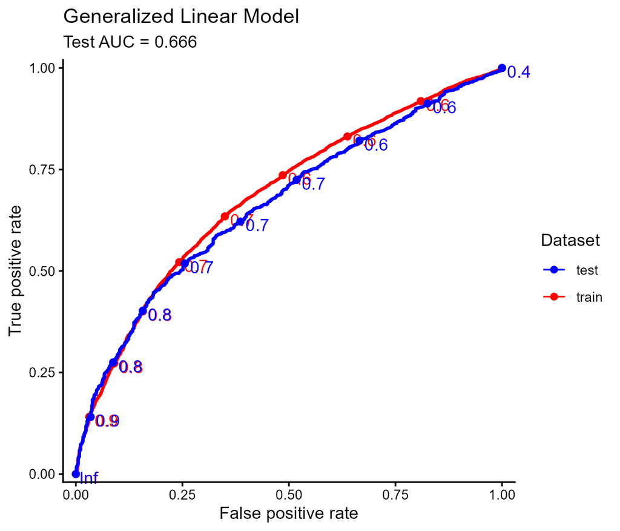

**Figure 12.** Receiving operating curve (ROC) analysis of the eight-donor egg IVF prediction models during its training and testing process.

#### regLR

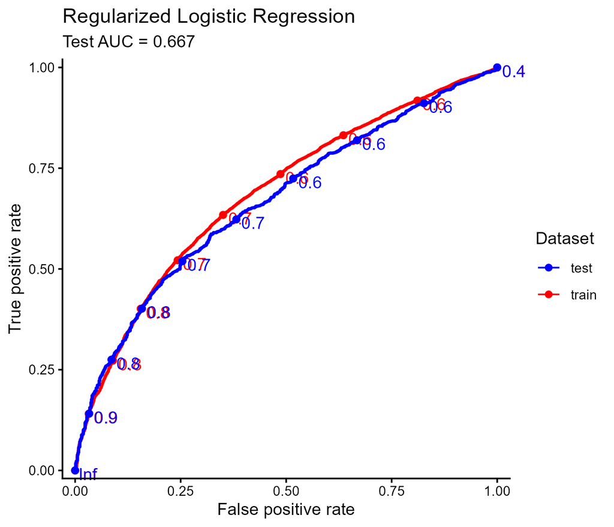

**Figure 13.** Receiving operating curve (ROC) analysis of the eight-donor egg IVF prediction models during its training and testing process.

#### DT

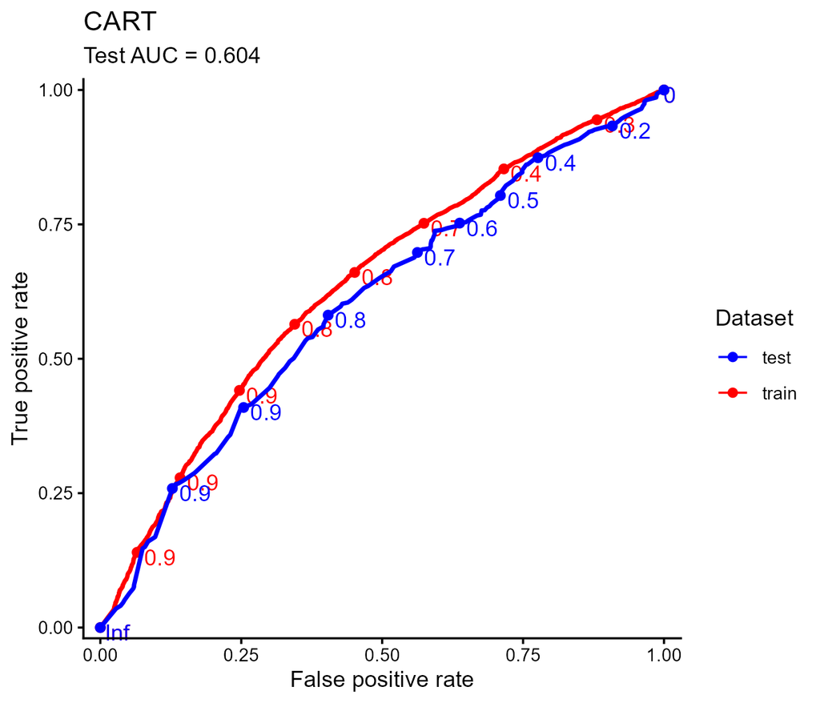

**Figure 14.** Receiving operating curve (ROC) analysis of the eight-donor egg IVF prediction models during its training and testing process.

#### RF

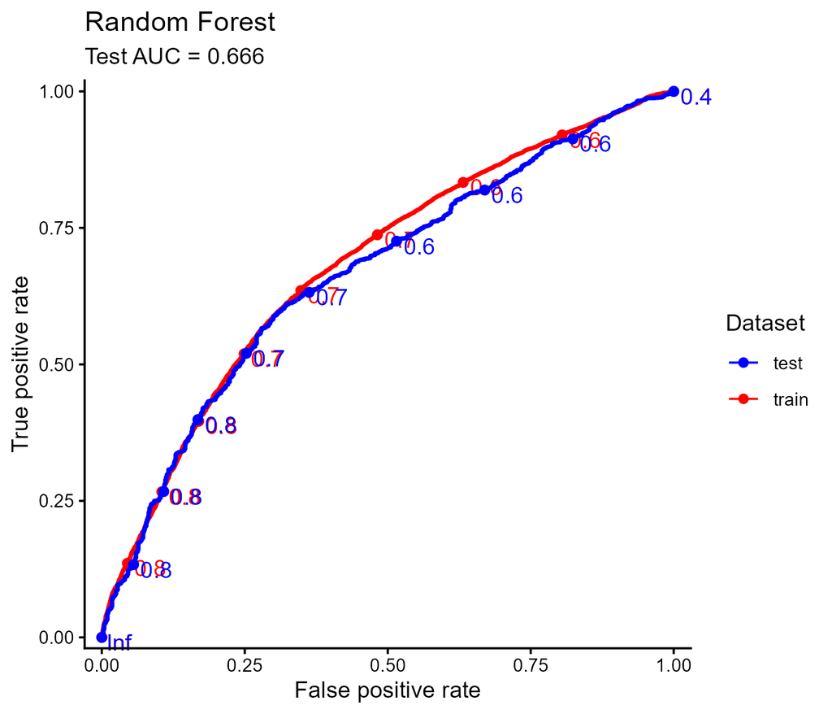

**Figure 15.** Receiving operating curve (ROC) analysis of the eight-donor egg IVF prediction models during its training and testing process.

#### GAM

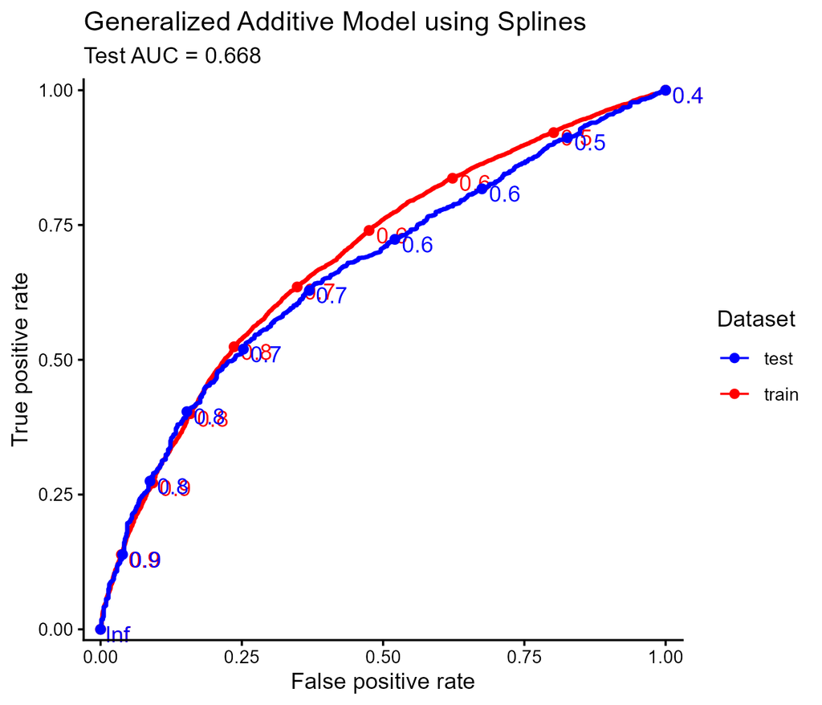

**Figure 16.** Receiving operating curve (ROC) analysis of the eight-donor egg IVF prediction models during its training and testing process.